# Bayesian (365) Final Project

Janine Yanes

This project utilizes 2 datasets.

One (`covid_dataset`) was found on DataHub, but was collected from a variety of sources by the Johns Hopkins University Center for Systems Science and Engineering (CSSE). A complete list of these sources can be found in the CSSE’s data repository (https://github.com/CSSEGISandData/COVID-19) as well as on the DataHub webpage where it was found (https://datahub.io/core/covid-19#resource-covid-19_zip). The data lists cumulative COVID-19 cases, recoveries, and deaths over time, from 1/22/2020 to 1/23/2022, for various countries. However, for this analysis, we will only be using the data for the New Jersey counties, `NJ_data`.

The other dataset (`county_population`) was collected by the US Census Bureau, through the American Community Survey. It contains the 2015-2019 estimates for the population size and density of each county in the United States. Once again, we will only be using the data for New Jersey, `county_population_NJ`.

The goal of this analysis is to see how time and population density affected the amount of COVID cases for each county in New Jersey, particularly after COVID vaccines became widely available after December 2020.

```r
#Load packages
library(ggplot2)
library(rstanarm)
library(bayesplot)
library(bayesrules)
library(tidyverse)
library(tidybayes)
library(broom.mixed)
library(jsonlite)
library(BTYD)
library(lubridate)
library(bayesmix)

#getting data
covid_file = 'https://datahub.io/core/covid-19/datapackage.json'
covid_dataset = fromJSON(paste(readLines(covid_file), collapse=""))
US_data = read.csv(url(covid_dataset$resources$path[9]))
NJ_data = subset(US_data, Province.State == "New Jersey")
head(NJ_data)
```

|  | Date | Admin2 | Province.State | Confirmed | Deaths | Country.Region |
| --- | --- | --- | --- | --- | --- | --- |
| 1351653 | 2020-01-22 | Atlantic | New Jersey | 0 | 0 | US |
| 1351654 | 2020-01-23 | Atlantic | New Jersey | 0 | 0 | US |
| 1351655 | 2020-01-24 | Atlantic | New Jersey | 0 | 0 | US |
| 1351656 | 2020-01-25 | Atlantic | New Jersey | 0 | 0 | US |
| 1351657 | 2020-01-26 | Atlantic | New Jersey | 0 | 0 | US |
| 1351658 | 2020-01-27 | Atlantic | New Jersey | 0 | 0 | US |

```r
setwd("/Users/yanes/Downloads") #setting directory: WILL HAVE TO BE CHANGED FOR OTHER USERS
county_population = read.csv("Population_-_Counties_2015-2019.csv")
county_population_NJ = subset(county_population, GEO_PARENT_NAME == "New Jersey")
head(county_population_NJ)
```

|  | OBJECTID | STATEFP | COUNTYFP | COUNTYNS | AFFGEOID | GEOID | NAME | LSAD | ALAND | AWATER | GEO_PARENT_NAME | POP_DENSITY | B01001_001E | B01001_001M | B09020_021E | B09020_021M | SHAPE_Length | SHAPE_Area |
| --- | --- | --- | --- | --- | --- | --- | --- | --- | --- | --- | --- | --- | --- | --- | --- | --- | --- | --- |
| 1775 | 1775 | 34 | 1 | 882270 | 0500000US34001 | 34001 | Atlantic | 6 | 1438776649 | 301268696 | New Jersey | 184.9523 | 266105 | 0 | 1498 | 229 | 1.976455 | 0.16537339 |
| 1776 | 1776 | 34 | 3 | 882271 | 0500000US34003 | 34003 | Bergen | 6 | 602911111 | 35354979 | New Jersey | 1543.1628 | 930390 | 0 | 4785 | 419 | 1.341217 | 0.06824726 |
| 1777 | 1777 | 34 | 5 | 882272 | 0500000US34005 | 34005 | Burlington | 6 | 2070157741 | 54113400 | New Jersey | 215.2986 | 445702 | 0 | 2535 | 365 | 2.351404 | 0.22365003 |
| 1778 | 1778 | 34 | 7 | 882273 | 0500000US34007 | 34007 | Camden | 6 | 573293905 | 15720557 | New Jersey | 883.9061 | 506738 | 0 | 2638 | 349 | 1.464989 | 0.06193295 |
| 1779 | 1779 | 34 | 9 | 882274 | 0500000US34009 | 34009 | Cape May | 6 | 651338862 | 955248161 | New Jersey | 142.9149 | 93086 | 0 | 976 | 246 | 1.523200 | 0.07714729 |
| 1780 | 1780 | 34 | 11 | 882275 | 0500000US34011 | 34011 | Cumberland | 6 | 1251898273 | 503713107 | New Jersey | 121.3405 | 151906 | 0 | 1600 | 304 | 2.028449 | 0.13573767 |

Here we will update `NJ_data` to make it easier to analyze and then plot the data. First, instead of having the data list cumulative COVID cases in each county for each day , we will make it so that it lists the incremental amount of COVID cases for each month, from 12/1/2020 to 12/1/2021. We will also make a column for months since 12/1/2020, so that the time passed can be measured in integers instead of dates.

Next, we will combine `NJ_data` and `county_population_NJ` so that `NJ_data` contains the population and population density for each county. After this, we will no longer need `county_population_NJ` since `NJ_data` will have all the relevant information.

Furthermore, we will have a column listing the amount of COVID cases for each month as a percentage of the county’s population. This is what will be using for analysis, rather than the number of cases, in order to reduce the effect of population size on the data.

After all that, we will be able to plot the data in order to see the relationship between months since 12/1/2020, percentage of the population infected, and county.

```r
#subsetting data so that it is monthly instead of daily
NJ_data$Dates_converted = as.Date(NJ_data$Date)
NJ_data = subset(NJ_data, as.numeric(format(NJ_data$Dates_converted, '%d')) == 1)
#converting dates to months since 12/1/2020
NJ_data$Months_since_12_1_20 = NA
NJ_data$Months_since_12_1_20 = interval(as.Date("2020-12-1"), NJ_data$Dates_converted) %/% months(1)
#converting cumulative COVID cases to monthly cases
NJ_data$Confirmed_monthly = NA
NJ_data$Confirmed_monthly[1] = NJ_data$Confirmed[1]
for (NJ_index in 2:nrow(NJ_data)) {
  NJ_data$Confirmed_monthly[NJ_index] = NJ_data$Confirmed[NJ_index] - NJ_data$Confirmed[NJ_index - 1]
  if (NJ_data$Admin2[NJ_index] != NJ_data$Admin2[NJ_index - 1]) {
    NJ_data$Confirmed_monthly[NJ_index] = NJ_data$Confirmed[NJ_index]
  }
  if(NJ_data$Confirmed_monthly[NJ_index] < 0) {
    NJ_data$Confirmed_monthly[NJ_index] = 0
  }
}
#subsetting data so that  it doesn't go past 1/22/21
NJ_data = subset(NJ_data, Months_since_12_1_20 >= 0 & Months_since_12_1_20 <= 12)
#renaming county name column to County in both datasets
NJ_data$County = NA
NJ_data$County = NJ_data$Admin2
county_population_NJ$County = NA
county_population_NJ$County = county_population_NJ$NAME
#adding population and population density from county_population_NJ to NJ_data
NJ_data$Population_density = NA
NJ_data$Population = NA
NJ_index = 1
while (NJ_index <= nrow(NJ_data)) {
  county = 1
  #if NJ_data has a county that is not in county_population, the data for that county is removed from NJ_data
  while (county_population_NJ$County[county] != NJ_data$County[NJ_index]) {
    county = county + 1
    if (county == (nrow(county_population_NJ) + 1)) {
      NJ_data = subset(NJ_data, County != NJ_data$County[NJ_index])
      break
    }
  }
  if (county == (nrow(county_population_NJ) + 1)) {
    next
  }
  #if the county is in both datasets, update the population and population density for all data values for that county
  for (county_update in 0:12) {
    NJ_data$Population_density[NJ_index + county_update] = county_population_NJ$POP_DENSITY[county]
    NJ_data$Population[NJ_index + county_update] = county_population_NJ$B01001_001E[county]
  }
  #move on to next county in NJ_data (each county has 13 data entries)
  NJ_index = NJ_index + 13
}
#converting County_Province_State to integers (each county has a different number)
NJ_data$County_ID = NA
county_ID = 1
NJ_index = 1
while (NJ_index <= length(NJ_data$County)) {
  for (count in 1:13) {
    NJ_data$County_ID[NJ_index] = county_ID
    NJ_index = NJ_index + 1
  }
  county_ID = county_ID + 1
}
#converting monthly cases into percentage of population infected that month (1% of population means Confirmed_monthly_percentage = 1)
NJ_data$Confirmed_monthly_percentage = NA
NJ_data$Confirmed_monthly_percentage = (NJ_data$Confirmed_monthly / NJ_data$Population) * 100
#create a subset of NJ_data with relevant variables only
NJ_data = NJ_data %>%
  dplyr::select(Months_since_12_1_20, County, County_ID, Confirmed_monthly, Confirmed_monthly_percentage, Population, Population_density)
head(NJ_data)
```

|  | Months_since_12_1_20 | County | County_ID | Confirmed_monthly | Confirmed_monthly_percentage | Population | Population_density |
| --- | --- | --- | --- | --- | --- | --- | --- |
| 1351967 | 0 | Atlantic | 1 | 3591 | 1.3494673 | 266105 | 184.9523 |
| 1351998 | 1 | Atlantic | 1 | 5660 | 2.1269800 | 266105 | 184.9523 |
| 1352029 | 2 | Atlantic | 1 | 6367 | 2.3926645 | 266105 | 184.9523 |
| 1352057 | 3 | Atlantic | 1 | 3191 | 1.1991507 | 266105 | 184.9523 |
| 1352088 | 4 | Atlantic | 1 | 3435 | 1.2908438 | 266105 | 184.9523 |
| 1352118 | 5 | Atlantic | 1 | 2640 | 0.9920896 | 266105 | 184.9523 |

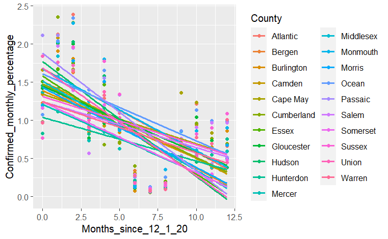

```r
write.csv(NJ_data, "C:\\Users\\yanes\\Downloads\\test.csv")
#plotting NJ_data
ggplot(NJ_data, aes(y = Confirmed_monthly_percentage, x = Months_since_12_1_20, color = County)) +
  geom_point() +
  geom_smooth(method = "lm", se = FALSE)
```

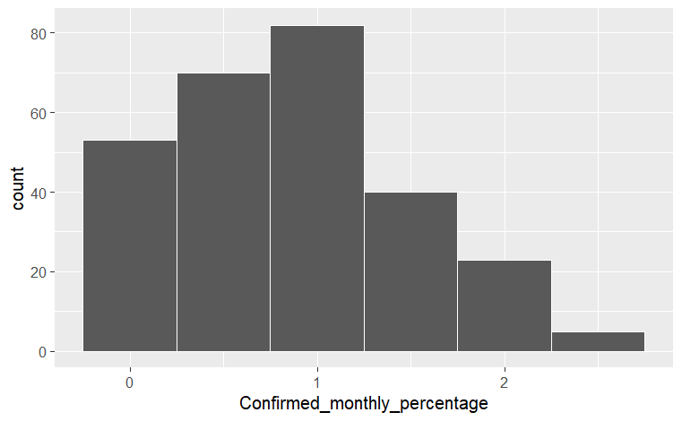

```r
ggplot(NJ_data, aes(x = Confirmed_monthly_percentage)) +
  geom_histogram(color = "white", binwidth = 0.5)
```

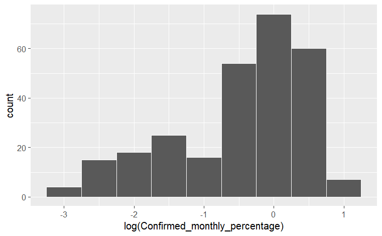

```r
ggplot(NJ_data, aes(x = log(Confirmed_monthly_percentage))) +
  geom_histogram(color = "white", binwidth = 0.5)
```

As you can see in the plot above, all of the counties seem to have a negative relationship between months since 12/1/2020 and confirmed COVID cases, although some relationships are more negative than others. Furthermore, no county has a particularly higher or lower amount of COVID cases than the other; they all overlap.

As for the distribution of `Confirmed_monthly_percentage`, it is positively skewed, rather than normal. Trying to use log(Confirmed_monthly_percentage) simply leads to it being skewed the other direction. This implies that we shouldn’t a normal regression model. Since the data is positively skewed and doesn’t use integers (i.e. a count), a Gamma model seems the most appropriate to use in `stan_glmer()`.

Just in case, we will simulate both a Gamma posterior model and a normal posterior model for NJ_data for comparison, using default priors. Both will be hierarchical models for `Confirmed_monthly_percentage`, with `Months_since_12_1_20` as an individual-level predictor and `Population_density` as a group-level predictor.

```r
#changing data points where Confirmed_monthly_percentage equals 0 to a minuscule amount
NJ_data["Confirmed_monthly_percentage"][NJ_data["Confirmed_monthly_percentage"] == 0] = 0.000000000000000001
NJ_model_gamma = stan_glmer(
  Confirmed_monthly_percentage ~ Population_density + Months_since_12_1_20 + (1 | County_ID),
  data = NJ_data, family = Gamma,
  chains = 5, iter = 10000*2, seed = 84735
)
NJ_model_normal = stan_glmer(
  Confirmed_monthly_percentage ~ Population_density + Months_since_12_1_20 + (1 | County_ID),
  data = NJ_data, family = gaussian,
  chains = 5, iter = 10000*2, seed = 84735
)
prior_summary(NJ_model_gamma)
```

```
Priors for model 'NJ_model_gamma'
------
Intercept (after predictors centered)
 ~ normal(location = 0, scale = 2.5)

Coefficients
  Specified prior:
    ~ normal(location = [0,0], scale = [2.5,2.5])
  Adjusted prior:
    ~ normal(location = [0,0], scale = [0.002,0.667])

Auxiliary (shape)
 ~ exponential(rate = 1)

Covariance
 ~ decov(reg. = 1, conc. = 1, shape = 1, scale = 1)
------
See help('prior_summary.stanreg') for more details
```

```r
prior_summary(NJ_model_normal)
```

```
Priors for model 'NJ_model_normal'
------
Intercept (after predictors centered)
  Specified prior:
    ~ normal(location = 0.87, scale = 2.5)
  Adjusted prior:
    ~ normal(location = 0.87, scale = 1.5)

Coefficients
  Specified prior:
    ~ normal(location = [0,0], scale = [2.5,2.5])
  Adjusted prior:
    ~ normal(location = [0,0], scale = [0.0012,0.3950])

Auxiliary (sigma)
  Specified prior:
    ~ exponential(rate = 1)
  Adjusted prior:
    ~ exponential(rate = 1.7)

Covariance
 ~ decov(reg. = 1, conc. = 1, shape = 1, scale = 1)
------
See help('prior_summary.stanreg') for more details
```

Here we will run diagnostics for both models and compare the two.

[figure not shown]

```r
mcmc_trace(NJ_model_gamma)
```

```r
neff_ratio(NJ_model_gamma)
```

```
                             (Intercept)                       Population_density                     Months_since_12_1_20
                                 0.90224                                  0.54984                                  0.92866
              b[(Intercept) County_ID:1]               b[(Intercept) County_ID:2]               b[(Intercept) County_ID:3]
                                 0.82600                                  0.88430                                  0.91658
              b[(Intercept) County_ID:4]               b[(Intercept) County_ID:5]               b[(Intercept) County_ID:6]
                                 0.89384                                  0.85336                                  0.86846
              b[(Intercept) County_ID:7]               b[(Intercept) County_ID:8]               b[(Intercept) County_ID:9]
                                 0.92182                                  0.89844                                  0.78180
             b[(Intercept) County_ID:10]              b[(Intercept) County_ID:11]              b[(Intercept) County_ID:12]
                                 0.82982                                  0.85824                                  0.92146
             b[(Intercept) County_ID:13]              b[(Intercept) County_ID:14]              b[(Intercept) County_ID:15]
                                 0.85038                                  0.86542                                  0.74368
             b[(Intercept) County_ID:16]              b[(Intercept) County_ID:17]              b[(Intercept) County_ID:18]
                                 0.89366                                  0.92152                                  0.87214
             b[(Intercept) County_ID:19]              b[(Intercept) County_ID:20]              b[(Intercept) County_ID:21]
                                 0.86864                                  0.90840                                  0.90664
                                   shape Sigma[County_ID:(Intercept),(Intercept)]
                                 1.07640                                  0.63008
```

```r
rhat(NJ_model_gamma)
```

```
                             (Intercept)                       Population_density                     Months_since_12_1_20
                               1.0000030                                1.0000737                                0.9999585
              b[(Intercept) County_ID:1]               b[(Intercept) County_ID:2]               b[(Intercept) County_ID:3]
                               0.9999680                                0.9999890                                1.0001394
              b[(Intercept) County_ID:4]               b[(Intercept) County_ID:5]               b[(Intercept) County_ID:6]
                               0.9999964                                1.0000020                                0.9999978
              b[(Intercept) County_ID:7]               b[(Intercept) County_ID:8]               b[(Intercept) County_ID:9]
                               1.0000322                                1.0000273                                0.9999497
             b[(Intercept) County_ID:10]              b[(Intercept) County_ID:11]              b[(Intercept) County_ID:12]
                               1.0001757                                1.0000876                                1.0000022
             b[(Intercept) County_ID:13]              b[(Intercept) County_ID:14]              b[(Intercept) County_ID:15]
                               0.9999655                                1.0000496                                1.0000540
             b[(Intercept) County_ID:16]              b[(Intercept) County_ID:17]              b[(Intercept) County_ID:18]
                               0.9999521                                1.0000526                                1.0000239
             b[(Intercept) County_ID:19]              b[(Intercept) County_ID:20]              b[(Intercept) County_ID:21]
                               1.0000621                                1.0000436                                0.9999702
                                   shape Sigma[County_ID:(Intercept),(Intercept)]
                               0.9999849                                1.0001809
```

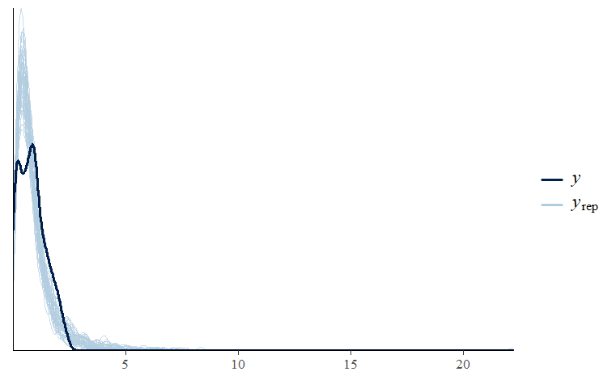

```r
pp_check(NJ_model_gamma)
```

[figure not shown]

```r
mcmc_trace(NJ_model_normal)
```

```r
neff_ratio(NJ_model_normal)
```

```
                             (Intercept)                       Population_density                     Months_since_12_1_20
                                 1.16856                                  1.08272                                  1.28596
              b[(Intercept) County_ID:1]               b[(Intercept) County_ID:2]               b[(Intercept) County_ID:3]
                                 0.97126                                  1.06802                                  1.11534
              b[(Intercept) County_ID:4]               b[(Intercept) County_ID:5]               b[(Intercept) County_ID:6]
                                 1.11124                                  1.05992                                  1.10882
              b[(Intercept) County_ID:7]               b[(Intercept) County_ID:8]               b[(Intercept) County_ID:9]
                                 1.07516                                  1.08530                                  0.90268
             b[(Intercept) County_ID:10]              b[(Intercept) County_ID:11]              b[(Intercept) County_ID:12]
                                 0.86488                                  0.86322                                  1.14804
             b[(Intercept) County_ID:13]              b[(Intercept) County_ID:14]              b[(Intercept) County_ID:15]
                                 0.91302                                  1.05180                                  0.82836
             b[(Intercept) County_ID:16]              b[(Intercept) County_ID:17]              b[(Intercept) County_ID:18]
                                 1.09794                                  1.12340                                  0.86980
             b[(Intercept) County_ID:19]              b[(Intercept) County_ID:20]              b[(Intercept) County_ID:21]
                                 1.12900                                  1.13934                                  1.06948
                                   sigma Sigma[County_ID:(Intercept),(Intercept)]
                                 1.27024                                  0.62812
```

```r
rhat(NJ_model_normal)
```

```
                             (Intercept)                       Population_density                     Months_since_12_1_20
                               1.0000039                                0.9999832                                0.9999335
              b[(Intercept) County_ID:1]               b[(Intercept) County_ID:2]               b[(Intercept) County_ID:3]
                               0.9999931                                1.0000970                                0.9999553
              b[(Intercept) County_ID:4]               b[(Intercept) County_ID:5]               b[(Intercept) County_ID:6]
                               0.9999808                                0.9999402                                1.0000264
              b[(Intercept) County_ID:7]               b[(Intercept) County_ID:8]               b[(Intercept) County_ID:9]
                               0.9999827                                1.0000179                                0.9999788
             b[(Intercept) County_ID:10]              b[(Intercept) County_ID:11]              b[(Intercept) County_ID:12]
                               1.0000070                                1.0000640                                1.0000581
             b[(Intercept) County_ID:13]              b[(Intercept) County_ID:14]              b[(Intercept) County_ID:15]
                               1.0000212                                0.9999924                                0.9999854
             b[(Intercept) County_ID:16]              b[(Intercept) County_ID:17]              b[(Intercept) County_ID:18]
                               0.9999278                                1.0000360                                1.0000359
             b[(Intercept) County_ID:19]              b[(Intercept) County_ID:20]              b[(Intercept) County_ID:21]
                               0.9999472                                0.9999703                                0.9999678
                                   sigma Sigma[County_ID:(Intercept),(Intercept)]
                               0.9999725                                1.0000138
```

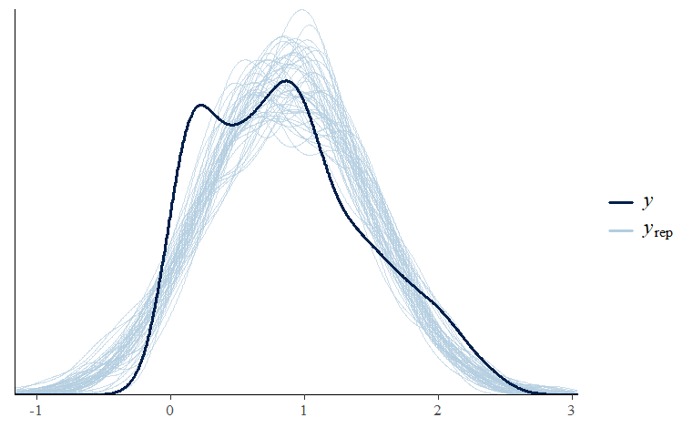

```r
pp_check(NJ_model_normal)
```

```r
loo_gamma <- loo(NJ_model_gamma)
loo_normal <- loo(NJ_model_normal)
loo_gamma$estimates
```

```
            Estimate         SE
elpd_loo -175.989535  9.4965564
p_loo       3.450584  0.2705806
looic     351.979069 18.9931129
```

```r
loo_normal$estimates
```

```
            Estimate         SE
elpd_loo -180.300380  8.7038889
p_loo       5.708435  0.4434246
looic     360.600759 17.4077779
```

```r
loo_compare(loo_gamma, loo_normal)
```

```
                elpd_diff se_diff
NJ_model_gamma   0.0       0.0
NJ_model_normal -4.3       9.2
```

```r
NJ_model = NJ_model_gamma
tidy(NJ_model, effects = c("fixed", "aux"),
     conf.int = TRUE, conf.level = 0.90)
```

| term | estimate | std.error | conf.low | conf.high |
| --- | --- | --- | --- | --- |
| (Intercept) | 5.460605e-01 | 6.841290e-02 | 4.371498e-01 | 0.6642134081 |
| Population_density | 1.371801e-05 | 3.794694e-05 | -4.483744e-05 | 0.0000803264 |
| Months_since_12_1_20 | 1.353609e-01 | 1.368651e-02 | 1.132094e-01 | 0.1579841853 |
| shape | 2.101718e+00 | 1.693391e-01 | 1.835768e+00 | 2.3940874781 |
| mean_PPD | 8.688285e-01 | 5.718908e-02 | 7.802650e-01 | 0.9682773838 |

Lastly, let’s use the model to make predictions for Somerset County, which should have a County_ID of 18.

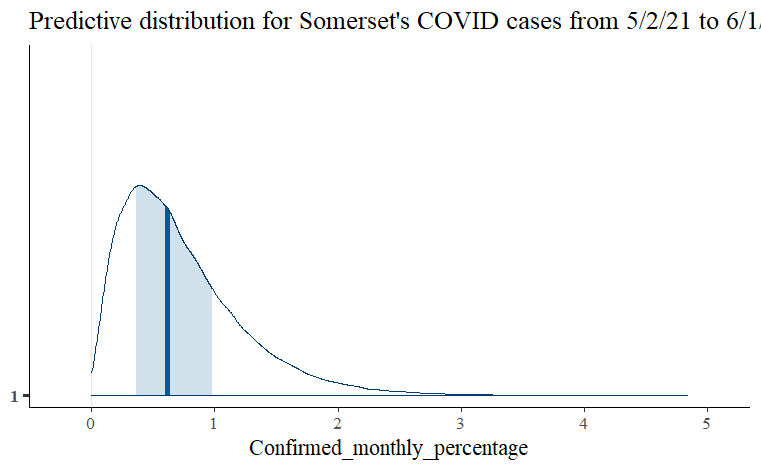

```r
Somerset_pop_density = subset(NJ_data, County == "Somerset")[1,3]
NJ_predict <- posterior_predict(
  NJ_model,
  newdata = data.frame(Months_since_12_1_20 = c(6), Population_density = c(Somerset_pop_density), County_ID = c(18),
            County = "Somerset"))
mcmc_areas(NJ_predict) +
  ggtitle("Predictive distribution for Somerset's COVID cases from 5/2/21 to 6/1/21") +
  xlab("Confirmed_monthly_percentage")
```

HONOR PLEDGE: On my honor, I have neither received nor given any unauthorized assistance on this project Janine Yanes